# Spatial Mixed-Effects Modelling

Nicolas Canete and Ellis Patrick

Westmead Institute for Medical Research, University of Sydney, Australia  
School of Mathematics and Statistics, University of Sydney, Australia

ncan4475@uni.sydney.edu.au

16 February 2020

#### Package

spicyR 0.1.0

# Contents

```r
# load required packages
library(spicyR)
library(SegmentedCellExperiment)
library(ggplot2)
```

# 1 Overview

The folowing will provide a step-by-step guide on how to use mixed-effects models to analyse multiple image datasets.

# 2 mixed-effects modelling

## 2.1 Reading in the data

Here, we use a melanoma image dataset with two conditions: Responders and Non-Responders.

```r
head(location(cells))
```

```
## DataFrame with 6 rows and 6 columns
##       imageID      cellID imageCellID         x         y      cellType
##   <character> <character> <character> <numeric> <numeric>      <factor>
## 1           1      cell_1      cell_1      49.5      1.25 CD8-PD1-PDL1-
## 2           1      cell_2      cell_2        85         1 CD8-PD1-PDL1-
## 3           1      cell_3      cell_3       169      1.25        SOX10+
## 4           1      cell_4      cell_4       245         1 CD8-PD1-PDL1-
## 5           1      cell_5      cell_5       291         1        SOX10+
## 6           1      cell_6      cell_6      2.75      1.25 CD8-PD1-PDL1-
```

```r
head(phenotype(cells))
```

```
## DataFrame with 6 rows and 3 columns
##      imageID      condition      donor
##    <numeric>       <factor>   <factor>
## 1          1 Non-Responders SP12-18569
## 2          2 Non-Responders SP12-18569
## 3          3 Non-Responders SP12-18569
## 4          4 Non-Responders SP12-18569
## 5          5 Non-Responders SP12-18569
## 21        21 Non-Responders SP13-11092
```

Note that `cellType` can be some combination of the expression of CD8, PD1 or PDL1, or is SOX10+.

## 2.2 Obtaining measure of localisation

Here, we use the `pairwise` funciton to measure the degree of pairwise localisation between CD8+PD1+PDL1+ cells.

```r
pairwiseVals <- getPairwise(cells, from = "CD8+PD1+PDL1+", to = "CD8+PD1+PDL1+")
```

We can produce boxplots to see if any differences exist within our two conditions.

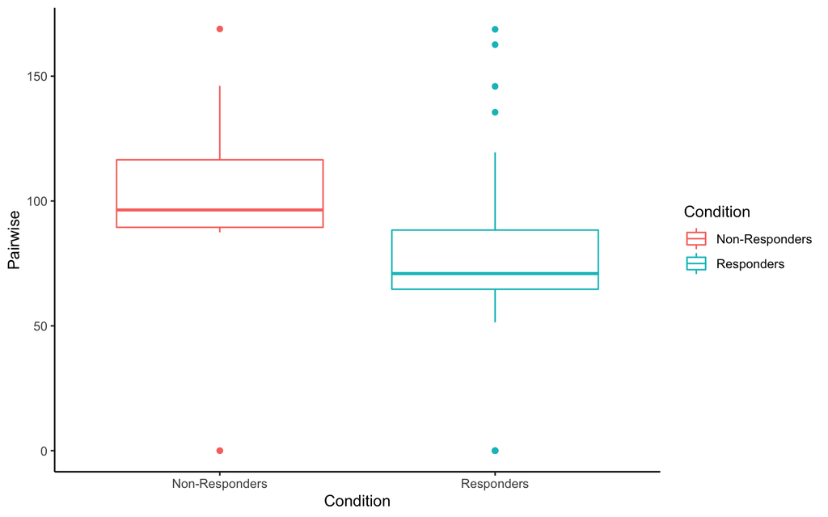

```r
spatialData <- data.frame(Pairwise = pairwiseVals,
                          Condition = phenotype(cells)$condition)

ggplot(spatialData, aes(x=Condition, y=Pairwise, color = Condition)) +
    geom_boxplot() +
    theme_classic()
```

## 2.3 Performing mixed-effects modelling

Now we need to obtain a vector of the corresponding donor, condition, and cell counts for each image.

```r
donor <- phenotype(cells)$donor
condition <- phenotype(cells)$condition

cellSplit <- location(cells, bind = FALSE)
count <- unlist(lapply(cellSplit,
                       function(x) sum(x$cellType == "CD8+PD1+PDL1+")))
count <- as.numeric(count)
```

Finally, we can use `spatialREM` to perform mixed-effects modelling.

```r
mixed.lmer <- spatialREM(pairwiseVals,
                         donor = donor,
                         condition = condition,
                         count1 = count,
                         count2 = count)

summary(mixed.lmer)
```

```
## Linear mixed model fit by REML. t-tests use Satterthwaite's method [
## lmerModLmerTest]
## Formula: Pair ~ Condition + (1 | Donor)
##    Data: spatialData
## Weights: w
##
## REML criterion at convergence: 756.2
##
## Scaled residuals:
##      Min       1Q   Median       3Q      Max
## -2.56304 -0.35255 -0.03582  0.47350  2.74344
##
## Random effects:
##  Groups   Name        Variance Std.Dev.
##  Donor    (Intercept) 47.780   6.912
##  Residual              7.185   2.680
## Number of obs: 80, groups:  Donor, 22
##
## Fixed effects:
##                     Estimate Std. Error      df t value Pr(>|t|)
## (Intercept)          102.283      9.266  39.618   11.04 1.18e-13 ***
## ConditionResponders  -28.089      9.961  33.242   -2.82  0.00804 **
## ---
## Signif. codes:  0 '***' 0.001 '**' 0.01 '*' 0.05 '.' 0.1 ' ' 1
##
## Correlation of Fixed Effects:
##             (Intr)
## CndtnRspndr -0.930
```

Here we find that there is a decrease in the localisation of CD8+PD1+PDL1+ cells between the Non-Responders and the Responders, with a p-value of 0.00804.

## 2.4 Performing random effects modelling and bootstrapping

To obtain more precise p-values, we can use bootstrap by resampling the data and using the gradient as a statistic. This is performed using `spatialREMBootstrap`.

```r
set.seed(51773)
pVal <- spatialREMBootstrap(mixed.lmer, nsim = 999)
pVal
```

```
## Greater  Lesser
##       1       0
```

Again, we find that there is a decrease in the localisation of CD8+PD1+PDL1+ cells between the Non-Responders and the Responders, with a p-value of 0.

# 3 Mixed-effects modelling on all pairwise cell type combinations

We can perform mixed-effects modelling as above on all pairwise cell type combinations using `spatialREMMulti`. We can specify whether or not to use bootstrapping to obtain p-values by setting the parameter `nsim`. For speed, we simply set it to the default `NULL`.

```r
df <- spatialREMMulti(cells, nsim = NULL)
```

[output not shown]

```r
head(df)
```

```
##            From            To    Greater     Lesser
## 1 CD8-PD1-PDL1- CD8-PD1-PDL1- 0.05650429 1.00000000
## 2        SOX10+ CD8-PD1-PDL1- 1.00000000 0.04202178
## 3 CD8+PD1+PDL1- CD8-PD1-PDL1- 0.17435098 1.00000000
## 4 CD8-PD1+PDL1- CD8-PD1-PDL1- 0.07138021 1.00000000
## 5 CD8+PD1-PDL1- CD8-PD1-PDL1- 1.00000000 0.50141397
## 6 CD8+PD1+PDL1+ CD8-PD1-PDL1- 1.00000000 0.56721904
```

We get a data frame of p-values for each pairwise comparison. We can represent this as a heatmap using the `spatialREMMultiPlot` function.

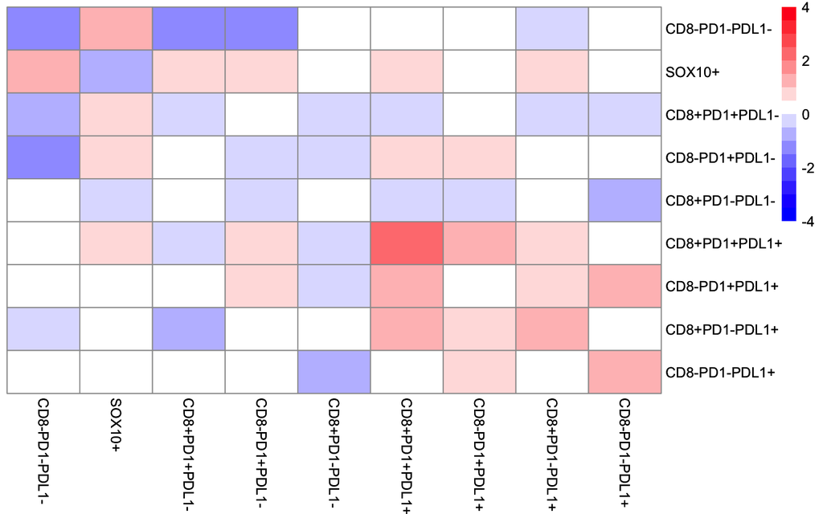

```r
spatialREMMultiPlot(df,
                    fdr = FALSE,
                    breaks = c(-4,4,0.5),
                    col=c("blue", "white", "red"))
```